# CWRU DSCI351-351m-451: w06a-f Predictive Analytics, Algorithms, Models

Profs: R. H. French, L. S. Bruckman, P. Leu, K. Davis, S. Cirlos

TAs: W. Oltjen, K. Hernandez, M. Li, M. Li, D. Colvin

06 October, 2022

#### Class Readings, Assignments, Syllabus Topics

##### Reading, Lab Exercises, SemProjects

- Readings:
  - For today: R4DS9-16
  - For next class: OIS6.1,2
- Laboratory Exercises:
  - LE3 : Is due Thursday midnight
  - LE4 : Will be distributed Thursday
  - LE4 is due Thursday October 20
- Office Hours: (Class Canvas Calendar for Zoom Link)
  - Mondays @ 4:30 PM to 5:30 PM
  - Wednesdays @ 4:30 PM to 5:30 PM
  - **Office Hours are on Zoom, and recorded**
    - MidTerm: Tuesday October 18th, in class or remote, 11:30 - 12:45 PM
    - Final: Monday December 19, 2022, 12:00PM - 3:00PM, Nord 356 or remote

#### Textbooks

- [Peng: R Programming for Data Science](https://leanpub.com/rprogramming)
- [Peng: Exploratory Data Analysis with R](https://leanpub.com/exdata)
- [Open Intro Stats, v4](https://openintro.org/os)
- [Wickham: R for Data Science](https://r4ds.had.co.nz/)
- [Hastie: Intro to Statistical Learning with R, 2nd Ed.](https://www.statlearning.com/)

Introduction to R and Data Science

- For R, Coding, Inferential Statistics
  - Peng: R Programming for Data Science
  - Peng: Exploratory Data Analysis with R

Textbooks for this class

- OIS = Diez, Barr, Çetinkaya-Runde: Open Intro Stat v4
- R4DS = Wickham, Grolemund: R for Data Science

Textbooks for DSCI353/353M/453, And in your Repo now

- ISLR = James, Witten, Hastie, Tibshirani: Intro to Statistical Learning with R 2nd Ed.
- ESL = Trevor Hastie, Tibshirani, Friedman: Elements of Statistical Learning
- DLwR = Chollet, Allaire: Deep Learning with R

Magazine Articles about Deep Learning

- DL1 to DL12 are “Deep Learning” articles in 3-readings/2-articles/

##### Tidyverse Cheatsheets, Functions and Reading Your Code

- Look at the Tidyverse Cheatsheet
  - **Tidyverse For Beginners Cheatsheet**
    - In the Git/20s-dsci353-353m-453-prof/3-readings/3-CheatSheets/ folder
  - **Data Wrangling with dplyr and tidyr Cheatsheet**

  Tidyverse Functions & Conventions
  - The pipe operator `%>%`
  - Use `dplyr::filter()` to subset data row-wise.
  - Use `dplyr::arrange()` to sort the observations in a data frame
  - Use `dplyr::mutate()` to update or create new columns of a data frame
  - Use `dplyr::summarize()` to turn many observations into a single data point
  - Use `dplyr::arrange()` to change the ordering of the rows of a data frame
  - Use `dplyr::select()` to choose variables from a tibble,
    - keeps only variables you mention
  - Use `dplyr::rename()` keeps all the variables and renames variables
    - rename(iris, petal_length = Petal.Length)
  - These can be combined using `dplyr::group_by()`
    - which lets you perform operations “by group”.
  - The `%in%` matches conditions provided by a vector using the c() function
  - The **forcats** package has tidyverse functions
    - for factors (categorical variables)
  - The **readr** package has tidyverse functions
    - to read_…, melt_… col_…, parse_… data and objects

Reading Your Code: Whenever you see

- The assignment operator `<-`, think **“gets”**
- The pipe operator, `%>%`, think **“then”**

##### Syllabus

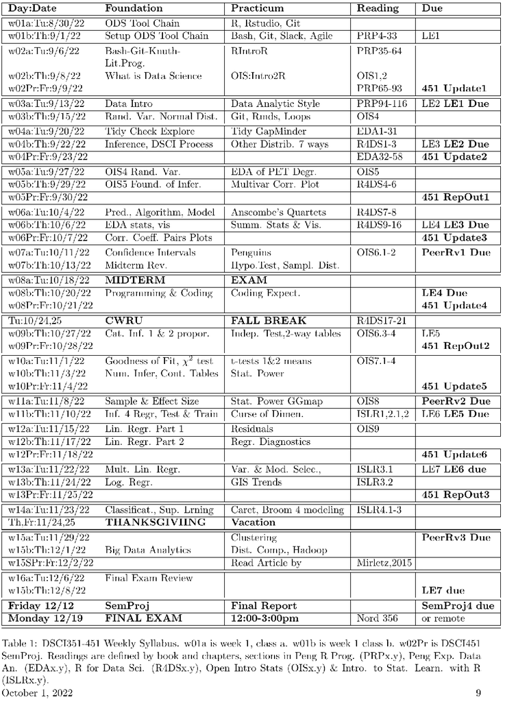

DSCI351-351M-451 Syllabus

### Basic steps we use to construct a data analysis.

- Modified from Jeff Leek’s slides
  - ( available in your repo in 17f-dsci351-451-prof/3-readings/ )

#### Data Analysis: Part a) Define Question

- Background on the research area and critical issues
- Define the question
- Define the ideal data set
- Determine what data you can access
- Define critical capabilities and identify packages you will draw upon
- Obtain the data, define you target data structure
- Clean and tidy the data

#### Data Analysis: Part b) Cleaning and EDA

- Write you databook, defining variables, units and data structures
- Data visualization and exploratory data analysis
- Observations of trends and functional forms
- Power transformations
- Validate with reference to domain knowledge
- Evaluate the types of Modeling Approaches to take

#### Data Analysis: Part c) Modeling and Statistical Learning

- Types of modeling to try
- Statistical prediction/modeling
- Model selection
- Cross-validation, Predictive R2
- Interpret results
- Challenge results

#### Data Analysis: Part d) Present your final models and learnings

- Present your results
- Present reproducible code
- Comparison to other modeling approaches in the literature

### Categories of data analyses

#### Supervised and Unsupervised Learning

- Two broad families of algorithms will be covered:
  - Unsupervised learning algorithms
  - Supervised learning algorithms

##### Unsupervised learning

- In unsupervised learning,
  - the algorithm will seek to find the structure that organizes unlabelled data.

##### Supervised learning

- In supervised learning,
  - we know the class or the level of some observations of a given target attribute.

#### Classification and Regression Problems

- There are basically two types of problems that predictive modeling deals with:
  - Classification problems
  - Regression problems

##### Classification

- In some cases, we want to predict which group an observation is part of.

Here, we are dealing with a quality of the observation.

##### Regression

- In other cases, we want to predict an observation’s level on an attribute.

Here, we are dealing with a quantity, and this is a regression problem.

#### The critical role of domain knowledge

- in modeling and prediction

Domain knowledge informs and is informed by data understanding.

- The understanding of the data
  - then informs how the data has to be prepared.

The next step is data modeling,

- which can also lead to further data preparation.

Data models have to be evaluated,

- and this evaluation can be informed by field knowledge,
  - which is also updated through the data mining process.

Finally,

- if the evaluation is satisfactory,
  - the models are deployed for prediction.

### Caveat: For Predictive Analytics

- Of course, predictions are not always accurate,
  - and some have written about the caveats of data science.

What do you think about the relationship between

- the attributes titled Predictor and Outcome on the following plot?

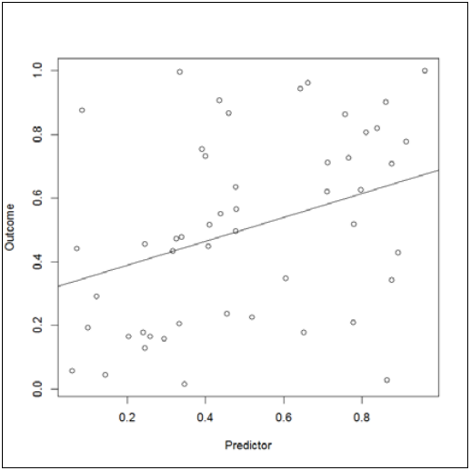

Relationship between Predictor & Outcome

It seems like there is a relationship between the two.

- For the statistically inclined,
  - I tested its significance:
    - r = 0.4195, p = .0024.
- The value p is the probability of obtaining a relationship of this strength or stronger
  - if there is actually no relationship between the attributes.
- ( This is the p-value of hypothesis testing, if p<0.05
  - typically we assert we can reject the null hypothesis)
- We could conclude that the relationship between these variables
  - in the population they come from is quite reliable,
  - **right?**

#### No: Lets think about this

- Believe it or not,
  - the population these observations come from
    - is that of randomly generated numbers.
  - We generated a data frame of 50 columns
    - of 50 randomly generated numbers.
  - We then examined all the correlations (manually)
    - and generated a scatterplot of the two attributes
    - with the largest correlation we found.

##### The code is provided here,

- We’ll use `runif()`
  - help(runif)
    - The Uniform Distribution
    - Description
    - These functions provide information about the uniform distribution
    - on the interval from min to max.
      - `dunif` gives the density,
      - `punif` gives the distribution function
      - `qunif` gives the quantile function and
      - `runif` generates random deviates.

```r
set.seed(1)
DF = data.frame(matrix(nrow = 50, ncol = 50))
for (i in 1:50) {
  DF[, i] = runif(50)
}

plot(DF[[2]], DF[[16]], xlab = "Predictor", ylab = "Outcome")
abline(lm(DF[[2]] ~ DF[[16]]))
cor.test(DF[[2]], DF[[16]])
```

- in case you want to check it yourself
- line 1 sets the seed so that you find the same results as we did,
- line 2 generates to the data frame,
- line 3-5 the for loop fills it with random numbers, column by column,
- line 7 generates the scatterplot,
- line 8 fits the regression line, and
- line 9 tests the significance of the correlation:

Normally we reject the null with a p-value of <0.05

- i.e. we’ll be wrong 5% of the time
  - in a set of 20 trials

Here we did 50 trials

- And cherry picked the best correlation
  - But its all randomly generated numbers
  - There is no predictive or causal relationship
- And we’d only recognize this if we consider
  - That our p-value is reported for 1 trial
  - But we run many trials

#### [Bonferroni Correction](https://en.wikipedia.org/wiki/Bonferroni_correction) for multiple comparisons

- How could this relationship happen given that the odds were 2.4 in 1000 ?
  - Well, think of it;
    - we correlated all 50 attributes 2 x 2,
    - which resulted in 2,450 tests
      - (not considering the correlation of each attribute with itself).
  - Such spurious correlation was quite expectable.

The usual threshold below which we consider a relationship significant is p = 0.05.

- This means that we expect to be wrong once in 20 times.
- You would be right to suspect that there are other significant correlations
  - in the generated data frame (there should be approximately 125 of them in total).
- This is the reason why we should always correct the number of tests.
- In our example,
  - as we performed 2,450 tests,
  - our threshold for significance
  - should be 0.0000204 (0.05 / 2450).
- This is called the Bonferroni correction.

### Overfitting: The need for Training and Testing Datasets

- Spurious correlations are always a possibility in data analysis
  - and this should be kept in mind at all times.

A related concept is that of overfitting.

- Overfitting happens, for instance,
  - when a weak classifier bases its prediction on the noise in data.
- We will discuss overfitting when discussing
  - Training datasets for fit a model to
  - Testing datasets for evaluating the goodness of fit
    - when using various types of cross-validation
  - And when evaluating $Predictive, Adjusted, R^2$

#### Lets get some basic ideas for background

- [Standard Error](https://en.wikipedia.org/wiki/Standard_error)
- [Margin of Error](https://en.wikipedia.org/wiki/Margin_of_error)
- [Z score](https://en.wikipedia.org/wiki/Standard_score)
  - [Used in Z-test](https://en.wikipedia.org/wiki/Z-test)
  - [The analog of Students t-test](https://en.wikipedia.org/wiki/Student%27s_t-test)
- [$Adjusted R^2$](https://en.wikipedia.org/wiki/Coefficient_of_determination)
- [PRESS, predicted residual error sum of squares statistic](https://en.wikipedia.org/wiki/PRESS_statistic)

#### Dice statistics

- [Weldon’s Dice](https://en.wikipedia.org/wiki/Raphael_Weldon#Weldon's_dice)
  - [Weldon’s Dice Automated](https://link.springer.com/article/10.1007%2Fs00144-009-0036-8)
  - Weldon’s Dice Revisited, In readings Kemp and Kemp - 1991 - Weldon’s Dice Data Revisited.pdf
- [Reproducing Weldon’s Dice Experiment](http://%20www.youtube.com/watch?v=95EErdouO2w)
- [Fair Dice (Part 2) - Numberphile](https://www.youtube.com/watch?v=8UUPlImm0dM)

### Doing Data Science

- Data Science is a melding of fields
- And has some tension among pre-existing scientific community cultures
  - e.g. Statisitics and Computer Science
- Stats traditionally focuses on Models and Uncertainty
- Computer Science focuses on Algorithms and “Data Products”

#### Twitter Data mining for EDA

- [deprecated twitter datamining](https://sites.google.com/site/miningtwitter/)
- [How to reveal anyone’s interests on Twitter using social network analysis](http://www.r-bloggers.com/how-to-reveal-anyones-interests-on-twitter-using-social-network-analysis/)
- [Twitter Network Analysis](http://www.eanalytica.com/blog/twitter-network-analysis-in-R/)
- [Graph Analysis of Twitter and people’s interests](http://cartesianfaith.com/2014/09/22/how-to-reveal-anyones-interests-on-twitter-using-social-network-analysis/)
- [Social Network Analysis](https://rdatamining.wordpress.com/2012/03/27/social-network-analysis-with-r/)

#### Word clouds for visualization

- [Shiny word clouds](http://shiny.rstudio.com/gallery/word-cloud.html)
- [Word clouds in R](http://onertipaday.blogspot.com/2011/07/word-cloud-in-r.html)

### Algorithms

- An algorithm is a procedure or set of steps or rules to accomplish a task.

Algorithms are one of the fundamental concepts in, or building blocks of, computer science:

- the basis of the design of elegant and efficient code,
  - data preparation and processing,
  - and software engineering.

Efficient algorithms that work sequentially or in parallel

- are the basis of pipelines to process and prepare data.

With respect to data science,there are at least three classes of algorithms one should be aware of:

1. Data munging, preparation, and processing algorithms,
- such as sorting, MapReduce, or Pregel.
2. Optimization algorithms for parameter estimation, including
- Stochastic Gradient Descent,
- Newton’s Method, and
- Least Squares.
- We mention these types of algorithms throughout,
- and they underlie many R functions.
3. Machine learning algorithms are a big topic
- and we discuss these more next.
- and in DSCI 353-353M-453
- They are covered in ISLR textbook

#### Machine Learning Algorithms

- Machine learning algorithms are largely used
  - to predict, classify, or cluster.

So modeling could be used to predict or classify? Yes.

- Here’s where some lines have been drawn that can make things a bit confusing,
- and it’s worth understanding who drew those lines.

Statistical modeling came out of statistics departments,

- and machine learning algorithms came out of computer science departments.
- Certain methods and techniques are considered to be part of both,
  - and you’ll see that we often use the words somewhat interchangeably.

You’ll find some of the methods, such as linear regression,

- in machine learning books as well as intro to statistics books.
- It’s not necessarily useful to argue over
  - who the rightful owner is of these methods,
- but it’s worth pointing out here that it can get
  - a little vague or ambiguous about what the actual difference is.

In general, machine learning algorithms

- that are the basis of artificial intelligence (AI)
  - such as image recognition,
  - speech recognition,
  - recommendation systems,
  - ranking and personalization of content
    - often the basis of data products
  - are not usually part of a core statistics curriculum or department.

They aren’t generally designed to infer the underlying generative process

- (e.g., to model something),
- but rather to predict or classify with the most accuracy.

### Statistician and Computer Science Approaches

- We say the following lovingly and with respect:
  - Statisticians have chosen to spend their lives investigating uncertainty,
    - and they’re never 100% confident about anything.
  - Software engineers like to build things.
  - They want to build models that predict the best they can,
    - but there are no concerns about uncertainty—just build it!

#### Interpreting Parameters (such as Estimators, Predictors)

- Statisticians think of the parameters
  - in their linear regression models
  - as having real-world interpretations,

And typically want to be able to find meaning

- in behavior or
- describe the real-world phenomenon corresponding to those parameters.

Whereas a software engineer or computer scientist

- might be wanting to build their linear regression algorithm
  - into production-level code,
- and the predictive model is what is known as a black box algorithm,

They don’t generally focus on the interpretation of the parameters.

- If they do, it is with the goal of handtuning them
- in order to optimize predictive power.

#### Confidence Intervals

- Statisticians provide confidence intervals and posterior distributions
  - for parameters and estimators,

And are interested in capturing the variability or uncertainty of the parameters.

- Many machine learning algorithms,
  - such as k-means or k-nearest neighbors,
  - don’t have a notion of confidence intervals or uncertainty.

#### The Role of Explicit Assumptions

- Statistical models make explicit assumptions
  - about data-generating processes and distributions,
  - and you use the data to estimate parameters.

Nonparametric solutions,

- don’t make any assumptions about probability distributions,
- or they are implicit.

#### So Is It An Algorithm Or A Model?

- While we tried to make a distinction between the two earlier,
  - we admit the colloquial use of the words “model” and “algorithm”
    - gets confusing because the two words seem to be used interchangeably
  - when their actual definitions are not the same thing at all.

In the purest sense,

- an algorithm is a set of rules or steps to follow
  - to accomplish some task.
- And a model is an attempt to describe or capture the world.

These two seem obviously different,

- so it seems the distinction should should be obvious.

Unfortunately, it isn’t. For example,

- regression can be described as a statistical model
  - as well as a machine learning algorithm.
- You’ll waste your time trying to get people to discuss this with any precision.

In some ways this is a historical artifact

- of statistics and computer science communities
- developing methods and techniques in parallel
  - and using different words for the same methods.

The consequence of this is that the distinction

- between machine learning and statistical modeling is muddy.

Some methods (for example, k-means, discussed in the next section)

- we might call an algorithm
- because it’s a series of computational steps
  - used to cluster or classify objects

On the other hand, k-means can be reinterpreted as

- a special case of a Gaussian mixture model.

The net result is that colloquially,

- people use the terms algorithm and model interchangeably
  - when it comes to a lot of these methods,
- so try not to let it worry you.
  - (Though it bothers us, too.)

### One basic algorithm: Linear Regression

- One of the most common statistical methods is linear regression.

At its most basic,

- it’s used when you want to express the mathematical relationship
  - between two variables or attributes.
- between a predictor and a response

When you use it, you are making the assumption

- that there is a linear relationship between
  - an outcome variable
    - (sometimes also called the response variable, dependent variable, or label) and a
  - predictor
    - (sometimes also called an independent variable, explanatory variable, or feature);

Or between

- one variable and several other variables,
- in which case you’re modeling the relationship as having a linear structure.

NOTE: the regression method (to fit the data) is a linear method. But Linear Regression can be used for fitting equations of higher order than linear

- So you can use linear regression to fit an exponential parametric equation to your data.
- For this reason I tend to just refer to “regression”,
- with a special case of “non-linear regression”
  - if we are using more complex regression fitting methods

One entry point for thinking about linear regression is

- to think about deterministic lines first.
- We learned back in grade school that we could describe
- a line with a slope and an intercept,
  - $y = f(x) = \beta_0 + \beta_1 * x$ .
- But the setting there was always deterministic.
  - Notice we don’t have the explicit error term $\epsilon$ listed.

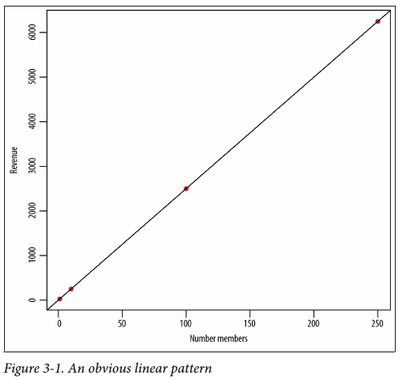

Looking at real data and regressing a linear function fit

So with real data, we have an equation,

- but there is an error between the fitline and the data
- RSS( $\beta$) = $\sigma_i$ ($y_i$ - $\beta_xi$)$^2$
- $y = f(x) = \beta_0 + \beta_1 * x + \epsilon$ .

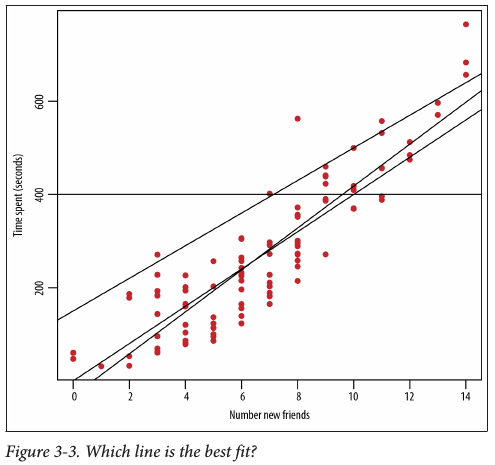

  with real data function

So which line fits best?

So we minimize the residual sum of squares (RSS) between the fitline and the data

- where in vector notation $\beta * x = \beta_0 + \beta_1 * x$

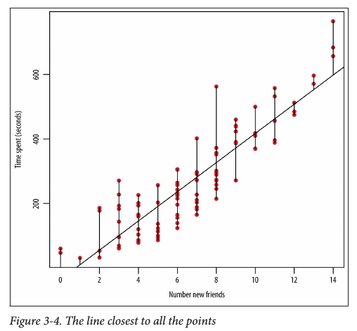

minimum RSS fitline and data

Estimators

- Here the little “hat” symbol on top of the $\beta$
  - 1. 5. $\hat{\beta}$
- indicates that it’s the estimator for $\beta$.

You don’t know the true value of $\beta$;

- all you have is the observed data,
- which you plug into the estimator to get an estimate.

The `lm` (linear model) function does all this for you in R

#### Regression: Evaluation metrics

- `summary(model)` will give you metrics and measures of the goodness of fit,

R-squared: This can be interpreted as the proportion of variance explained by our model.

- R-squared

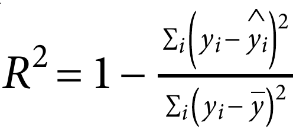

Rsquared

p-values: We can interpret the values in this column as follows:

- We are making a null hypothesis that the $\beta$s are zero.
- For any given $\beta$, the p-value captures
  - the probability of observing the data that we observed,
- and obtaining the test-statistic that we obtained under the null hypothesis.
- This means that if we have a low p-value,
  - it is highly unlikely to observe such a test-statistic
    - under the null hypothesis,
    - and the coefficient is highly likely to be nonzero
    - and therefore significant.

### Testing and Training datasets (or Cross-validation)

- Another approach to evaluating the model is as follows.
  - Divide our data up into a training set and a test set:
  - 80% in the training and 20% in the test.
    - I prefer 60% training, 40% test set
  - Fit the model on the training set,
    - then look at the mean squared error on the test set
    - and compare it to that on the training set.
  - Make this comparison across sample size as well.

If the mean squared errors are approximately the same,

- then our model generalizes well
- and we’re not in danger of overfitting. This approach is highly recommended.

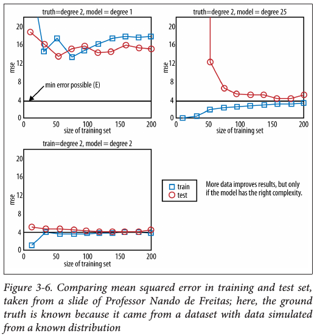

Test and Training datasets for model validation

#### Citations

- R Core Team. R: A Language and Environment for Statistical Computing. Vienna, Austria: R Foundation for Statistical Computing, 2014. http://www.R-project.org/.
- Gareth James, Daniela Witten, Trevor Hastie, and Robert Tibshirani. An Introduction to Statistical Learning: With Applications in R. 1st ed. 2013, Corr. 5th printing 2015 edition. Springer Texts in Statistics. New York: Springer, 2013.
- Diez, David M., Christopher D. Barr, and Mine Çetinkaya-Rundel. OpenIntro Statistics: Third Edition. 3 edition. S.l.: OpenIntro, Inc., 2015.
- Mayor, Eric. Learning Predictive Analytics with R. Packt Publishing - ebooks Account, 2015.